# DATA-413/613 HW 2: Tidyverse Review

Author

Ana Miranda

# 1 Analyze the English Open Word List

The [English Open Word List (EWOL)](https://github.com/kloge/The-English-Open-Word-List/tree/master) was developed to be more usable for computer word games (than the much larger ENABLE word list) by removing all words longer than 10 letters and all proper nouns and words requiring diacritical symbols, hyphens, and apostrophes. It was developed in 2005 so does not have many “modern” or slang words, e.g., blog or insta. It still has some words with unusual symbols caused by converting to Unicode (UTF-8) but they will not affect your results below.

1. The data is on the AU Data Science GitHub site in two formats. Each has the same data in a tibble with 128,985 words (rows).
   - The Rds format is a compressed version for sorting single R objects.
   - The parquet format is also a binary format designed by Apache for working with big data and storing the data in column-oriented (not row-oriented) format. To use parquet format install the {arrow} package. The file size is less than 50% of the Rds file.
- Load the data using one of the commands below and assign a variable name to it.

```r
#| name: load-eowl

library(tidyverse)
```

```r
e_words <- readRDS(url("https://raw.githubusercontent.com/AU-datascience/data/main/413-613/ewol_words.rds", "rb"))
```

- Use `str()` on the loaded data.

```r
str(e_words)
```

```
tibble [128,985 × 1] (S3: tbl_df/tbl/data.frame)
 $ word: chr [1:128985] "aa" "aah" "aal" "aalii" ...
```

2. Find “et”s.
1. The letters “e” and “t” are the most common in the English language. Find the words with the combination “et” appearing two or more times. Filter to just those words with the most “et”’s in them and sort so the longest words are on top. Use code to show words, the number of “et”s and their length. There should be 19 words.

```r
e_words %>%
  filter(str_detect(word, "et")) %>%
  mutate(count = str_count(word, "et"), length = str_length(word)) %>%
  filter(count >=2) %>%
  arrange(desc(length)) -> et_words_2more
et_words_2more
```

```
# A tibble: 19 × 3
   word       count length
   <chr>      <int>  <int>
 1 dietetical     2     10
 2 etiquettes     2     10
 3 hyetometer     2     10
 4 metathetic     2     10
 5 methinketh     2     10
 6 netiquette     2     10
 7 ninetieths     2     10
 8 tetraethyl     2     10
 9 tetrameter     2     10
10 dietetics      2      9
11 etiquette      2      9
12 foreteeth      2      9
13 metapelet      2      9
14 ninetieth      2      9
15 peetweets      2      9
16 dietetic       2      8
17 peetweet       2      8
18 zetetics       2      8
19 zetetic        2      7
```

2. Of these words with the most “et”’s, remove the words with the maximum length, then use a {dplyr} slice function (with default arguments) to show the five next longest words? Why do you get 6 words and not 5?

```r
et_words_2more %>%
  filter(length < max(length)) %>%
  slice_max(length, n=5, with_ties = TRUE)
```

```
# A tibble: 6 × 3
  word      count length
  <chr>     <int>  <int>
1 dietetics     2      9
2 etiquette     2      9
3 foreteeth     2      9
4 metapelet     2      9
5 ninetieth     2      9
6 peetweets     2      9
```

- **Answer:** Because there are ties in the ordering of the rows since all values are the same. In order to ignore ties, the default command “with_ties = TRUE” should be set to FALSE. See result below:

```r
et_words_2more %>%
  filter(length < max(length)) %>%
  slice_max(length, n=5, with_ties = F)
```

```
# A tibble: 5 × 3
  word      count length
  <chr>     <int>  <int>
1 dietetics     2      9
2 etiquette     2      9
3 foreteeth     2      9
4 metapelet     2      9
5 ninetieth     2      9
```

3. Use a tidyverse approach to find all words with an identical first and second half of the word. Show how many you got. You should get 151 words. DATA 613-students must solve using a regex pattern. Recommend creating a logical variable that captures if the word meets the criterion.
- If a word has an odd number of letters, exclude the middle character.
  - “murmur” counts because “mur” is both the first and second half.
  - “derider” counts because the middle “i” is excluded so “der” is both the first and second half.
- Save the results to a variable in a tibble that includes the original variables.

```r
e_words %>%
  mutate(n_letters = str_length(word)) %>%
  mutate(first_part = if_else((n_letters %% 2 == 0),
                               str_sub(word, 1, n_letters/2),
                               str_sub(word, 1, floor(n_letters/2))),
         sec_part =   if_else((n_letters %% 2 == 0),
                               str_sub(word, (n_letters/2)+1, n_letters),
                               str_sub(word, (ceiling(n_letters/2))+1, n_letters))
         ) %>%
  filter(first_part == sec_part) -> eq_fist_last_parts
eq_fist_last_parts
```

```
# A tibble: 151 × 4
   word  n_letters first_part sec_part
   <chr>     <int> <chr>      <chr>
 1 aa            2 a          a
 2 aba           3 a          a
 3 adrad         5 ad         ad
 4 aga           3 a          a
 5 aha           3 a          a
 6 aia           3 a          a
 7 ala           3 a          a
 8 algal         5 al         al
 9 ana           3 a          a
10 anan          4 an         an
# ℹ 141 more rows
```

4. Use the results from 3 to find and show the longest word(s) with an identical first and second half of the word. There should be four words.

```r
eq_fist_last_parts %>%
  group_by(n_letters) %>%
  count()
```

```
# A tibble: 9 × 2
# Groups:   n_letters [9]
  n_letters     n
      <int> <int>
1         2     2
2         3    52
3         4    20
4         5    24
5         6    30
6         7     6
7         8    13
8         9     3
9        10     1
```

```r
eq_fist_last_parts %>%
  arrange(desc(n_letters)) %>%
  slice_max(n_letters, n=4)
```

```
# A tibble: 4 × 4
  word       n_letters first_part sec_part
  <chr>          <int> <chr>      <chr>
1 quinaquina        10 quina      quina
2 overcover          9 over       over
3 tarantara          9 tara       tara
4 trinitrin          9 trin       trin
```

# 2 Country Names

The goal is to create an updated country code data frame with the original and world bank names, where they exist, along with a set of new names without punctuation. You are not allowed to rename any existing variables.

1. Load the {gapminder} package so you can access the `country_codes` data frame. Use a {readr} function and relative path to read in the World Bank data in `wb_country_income_classification_2023.csv` in the `data` folder.
- These two data sets are *not* consistent on all of the country names.
- Show the variable names for each data set

```r
#install.packages("gapminder")
library(gapminder)

#help(gapminder)

glimpse(gapminder)
```

```
Rows: 1,704
Columns: 6
$ country   <fct> "Afghanistan", "Afghanistan", "Afghanistan", "Afghanistan", …
$ continent <fct> Asia, Asia, Asia, Asia, Asia, Asia, Asia, Asia, Asia, Asia, …
$ year      <int> 1952, 1957, 1962, 1967, 1972, 1977, 1982, 1987, 1992, 1997, …
$ lifeExp   <dbl> 28.801, 30.332, 31.997, 34.020, 36.088, 38.438, 39.854, 40.8…
$ pop       <int> 8425333, 9240934, 10267083, 11537966, 13079460, 14880372, 12…
$ gdpPercap <dbl> 779.4453, 820.8530, 853.1007, 836.1971, 739.9811, 786.1134, …
```

- **Answer:** Observation: The {gapminder} data frame does not contain country codes in it and only country names.

```r
wd_country_income <- read_csv("../data/wb_country_income_classification_2023.csv",
                              col_names = TRUE,
                              na = c("NA", "..", ""),
                              skip_empty_rows = TRUE,
                              n_max = 267)
glimpse(wd_country_income)
```

```
Rows: 267
Columns: 5
$ Economy            <chr> "Afghanistan", "Albania", "Algeria", "American Samo…
$ Code               <chr> "AFG", "ALB", "DZA", "ASM", "AND", "AGO", "ATG", "A…
$ Region             <chr> "South Asia", "Europe & Central Asia", "Middle East…
$ `Income group`     <chr> "Low income", "Upper middle income", "Upper middle …
$ `Lending category` <chr> "IDA", "IBRD", "IBRD", NA, NA, "IBRD", "IBRD", "IBR…
```

```r
names(wd_country_income) <- c("economy" ,
                              "code"    ,
                              "region" ,
                              "income_group" ,
                              "lending_category")
glimpse(wd_country_income)
```

```
Rows: 267
Columns: 5
$ economy          <chr> "Afghanistan", "Albania", "Algeria", "American Samoa"…
$ code             <chr> "AFG", "ALB", "DZA", "ASM", "AND", "AGO", "ATG", "ARG…
$ region           <chr> "South Asia", "Europe & Central Asia", "Middle East &…
$ income_group     <chr> "Low income", "Upper middle income", "Upper middle in…
$ lending_category <chr> "IDA", "IBRD", "IBRD", NA, NA, "IBRD", "IBRD", "IBRD"…
```

2. Use a {dplyr} filtering join function to get the gapminder country_codes `country` values that are **not in** the World Bank data frame `Economy` variable. Show just the values for the `country` names not in the World Bank data. There should be 23 countries.

```r
#shows only what is in x and not in y.
gapminder_names_only = anti_join(gapminder, wd_country_income, by = join_by("country" == "economy"))

gapminder_names_only %>%
  group_by(country) %>%
  count()
```

```
# A tibble: 14 × 2
# Groups:   country [14]
   country                   n
   <fct>                 <int>
 1 Cote d'Ivoire            12
 2 Czech Republic           12
 3 Egypt                    12
 4 Gambia                   12
 5 Hong Kong, China         12
 6 Iran                     12
 7 Korea, Dem. Rep.         12
 8 Reunion                  12
 9 Sao Tome and Principe    12
10 Swaziland                12
11 Syria                    12
12 Taiwan                   12
13 Turkey                   12
14 Venezuela                12
```

- **Answer:** I only found 14 country names (not 23) that are in the {gapminder} data only and not in the World Bank data base.
3. Use a {dplyr} mutating join function to add the country names in World Bank `Economy` to the `country_codes` data frame in a new variable called `wb_name` **for only those countries that are in the {gapminder} `country_codes` data frame**. There should be 187 countries.
- Save to a data frame called `country_codes_wb` and show its first 5 rows.
- **Answer:** Observation: Couldn’t understand where to get the country_codes from since the “gapminder” data doesn’t have the country code variable to be used in the merge, that way making it impossible to fix the names.
4. Use a {stringr} function with regex `[:punct:]` to filter to only the rows in `country_codes_wb` where the world bank names use some form of punctuation. Save the resulting data frame with a new name and show only those rows. There should be 17.
- Note: the accent circumflex “^” does not count as punctuation but as part of a letter as it is a [diacritical mark](https://en.wikipedia.org/wiki/Diacritic).
5. Start with the data frame with the 17 countries found in 4. Create a new column in the data frame where the values are created as follows.
- Use {stringr} functions with regex to:
1. Replace all of the punctuation **or** white spaces in `wb_name` values, with an underscore, `_`, and then,
2. Remove any trailing underscores, `_`, and then,
3. Replace any double underscores, `__`, with a single `_`.
4. Use an argument of `mutate()` to ensure the new column is **right after `country`**
- The second row value should look like `Congo_Dem_Rep`.
- There is no need to do the replacements in a single step; three steps is fine.

# 3 Global Protest Tracker

1. Use a function from the {readxl} package to load the `Global Protest Tracker.xlsx` excel file. It has data from the Carnegie Foundation Endowment for Peace [Global Protest Tracker](https://carnegieendowment.org/features/global-protest-tracker?lang=en) on 715 protests from around the world. Go to the website and click on the `About the tracker` inset pop up on the right to get a pop-up window where you can look at definitions for select variables.
   - Review the data and use an argument for the function to ensure the data loads correctly with 715 rows and 21 columns.
   - Use `glimpse()` to see a summary of the data.

```r
#install.packages("readxl")
library(readxl)

global_protest_tracker <- read_excel("../data/Global Protest Tracker.xlsx",
                                     skip = 3,
                                     n_max = 719)
glimpse(global_protest_tracker)
```

```
Rows: 715
Columns: 21
$ Country                                    <chr> "Netherlands", "Italy", "Ga…
$ `Protest Name`                             <chr> "Extinction Rebellion prote…
$ `Start Date`                               <chr> "23-May", "22-Jun", "21-May…
$ `Freedom Rating (Status)`                  <chr> "Free", "Free", "Not free",…
$ Triggers                                   <chr> "The climate activist group…
$ Motivations                                <chr> "Anger over the Dutch gover…
$ `Peak Size`                                <chr> ">10,000", "<100", ">1,000"…
$ `Key Participants`                         <chr> "Members of the group Extin…
$ Duration                                   <chr> "Active, intermittently", "…
$ Outcomes                                   <chr> "No policy/leadership chang…
$ `Active protests`                          <chr> "X", "X", "X", "X", "X", "X…
$ `Economic motivation?`                     <chr> NA, NA, NA, NA, "X", NA, NA…
$ `Political motivation?`                    <chr> "X", "X", "X", "X", "X", "X…
$ `Corruption motivation?`                   <chr> NA, NA, NA, NA, NA, NA, NA,…
$ `Size category`                            <chr> "Tens of thousands", "Tens"…
$ `Protests with a significant outcome`      <chr> NA, NA, NA, "X", NA, NA, NA…
$ `Large protests (Over 100,000 protesting)` <chr> NA, NA, NA, NA, NA, NA, NA,…
$ `Violent government response`              <chr> NA, NA, NA, "X", NA, "X", N…
$ `Long protests (more than 3 months)`       <chr> "X", "X", "X", "X", NA, "X"…
$ `Coronavirus-related protests`             <chr> NA, NA, NA, NA, NA, NA, NA,…
$ `Capital city`                             <chr> "Amsterdam", "Rome", "Gaza …
```

2. Clean Data
1. Convert `Start Date` to class `Date` by combining {stringr} and {lubridate} functions. Assume the protests start on the first of the month. Save to a data frame with a new name.
2. Note the warning that one row failed to parse. Find the row and determine the reason it did not parse. Adjust your code so that all rows parse properly. Hint: Use `dplyr::case_when()` to isolate and adjust the one row so it matches the others and then parse all rows again.
   - Save to original data frame
   - Show the number of non-`NA` values in `Start Date`. It should be 715.
   - Use an R command to remove the data frame from part 2.a from the Global Environment.

```r
global_protest_tracker %>%
  mutate(start_date_char = if_else(`Start Date` == "Mar-24", "24-Mar", `Start Date`),
         start_date = parse_date_time(start_date_char, "ym")
         ) -> gpt_newfile

 glimpse(gpt_newfile)
```

```
Rows: 715
Columns: 23
$ Country                                    <chr> "Netherlands", "Italy", "Ga…
$ `Protest Name`                             <chr> "Extinction Rebellion prote…
$ `Start Date`                               <chr> "23-May", "22-Jun", "21-May…
$ `Freedom Rating (Status)`                  <chr> "Free", "Free", "Not free",…
$ Triggers                                   <chr> "The climate activist group…
$ Motivations                                <chr> "Anger over the Dutch gover…
$ `Peak Size`                                <chr> ">10,000", "<100", ">1,000"…
$ `Key Participants`                         <chr> "Members of the group Extin…
$ Duration                                   <chr> "Active, intermittently", "…
$ Outcomes                                   <chr> "No policy/leadership chang…
$ `Active protests`                          <chr> "X", "X", "X", "X", "X", "X…
$ `Economic motivation?`                     <chr> NA, NA, NA, NA, "X", NA, NA…
$ `Political motivation?`                    <chr> "X", "X", "X", "X", "X", "X…
$ `Corruption motivation?`                   <chr> NA, NA, NA, NA, NA, NA, NA,…
$ `Size category`                            <chr> "Tens of thousands", "Tens"…
$ `Protests with a significant outcome`      <chr> NA, NA, NA, "X", NA, NA, NA…
$ `Large protests (Over 100,000 protesting)` <chr> NA, NA, NA, NA, NA, NA, NA,…
$ `Violent government response`              <chr> NA, NA, NA, "X", NA, "X", N…
$ `Long protests (more than 3 months)`       <chr> "X", "X", "X", "X", NA, "X"…
$ `Coronavirus-related protests`             <chr> NA, NA, NA, NA, NA, NA, NA,…
$ `Capital city`                             <chr> "Amsterdam", "Rome", "Gaza …
$ start_date_char                            <chr> "23-May", "22-Jun", "21-May…
$ start_date                                 <dttm> 2023-05-01, 2022-06-01, 20…
```

3. Convert `Peak Size` to numeric. Assume the values are equalities instead of `<` or `.` and convert `"Tens of thousands"` to `"20000"` and `"Thousands"` to `"3000"`. Save to the data frame.
- DATA 613 students must use regex with {stringr} detect and replace functions to convert values of all single digit million to the correct value and one regex to convert all fractional million rows (e.g. `"1.2 million"`) to their correct values. Consider using `?` and groups.
- Hint: Use `dplyr::case_when()` to identify the five cases (`"Thousands"`, `"Tens of thousands"`, single digit million, fractional millions, and `"unknown"`, plus the `.default =` `Peak Size` and for each case, use the right hand side formula to convert the values to the indicated character value, e.g., `"1.2 million"` becomes `"1,200,000"`. Then use a {readr} function to convert `Peak Size` from character to numeric.

```r
gpt_newfile %>%
  mutate(peak_size = if_else(`Peak Size` == "Tens of thousands", "20000",
                     if_else(`Peak Size` == "Thousands", "3000",
                     if_else(`Peak Size` == "Unknown", "", `Peak Size`
                             )))) %>%

  mutate(peak_size = str_replace_all(peak_size, "^(>|<)", ""),
         peak_size = str_replace_all(peak_size, " million", "00,000"),
         peak_size = str_replace_all(peak_size, ",+", ""),
         peak_size = str_replace_all(peak_size, "\\.", "")
         ) %>%

  mutate(peak_size_claen = str_trim(peak_size, side = "both"),
         peak_size_num = parse_number(peak_size_claen)
        ) -> gpt_newfile_clean

glimpse(gpt_newfile_clean)
```

```
Rows: 715
Columns: 26
$ Country                                    <chr> "Netherlands", "Italy", "Ga…
$ `Protest Name`                             <chr> "Extinction Rebellion prote…
$ `Start Date`                               <chr> "23-May", "22-Jun", "21-May…
$ `Freedom Rating (Status)`                  <chr> "Free", "Free", "Not free",…
$ Triggers                                   <chr> "The climate activist group…
$ Motivations                                <chr> "Anger over the Dutch gover…
$ `Peak Size`                                <chr> ">10,000", "<100", ">1,000"…
$ `Key Participants`                         <chr> "Members of the group Extin…
$ Duration                                   <chr> "Active, intermittently", "…
$ Outcomes                                   <chr> "No policy/leadership chang…
$ `Active protests`                          <chr> "X", "X", "X", "X", "X", "X…
$ `Economic motivation?`                     <chr> NA, NA, NA, NA, "X", NA, NA…
$ `Political motivation?`                    <chr> "X", "X", "X", "X", "X", "X…
$ `Corruption motivation?`                   <chr> NA, NA, NA, NA, NA, NA, NA,…
$ `Size category`                            <chr> "Tens of thousands", "Tens"…
$ `Protests with a significant outcome`      <chr> NA, NA, NA, "X", NA, NA, NA…
$ `Large protests (Over 100,000 protesting)` <chr> NA, NA, NA, NA, NA, NA, NA,…
$ `Violent government response`              <chr> NA, NA, NA, "X", NA, "X", N…
$ `Long protests (more than 3 months)`       <chr> "X", "X", "X", "X", NA, "X"…
$ `Coronavirus-related protests`             <chr> NA, NA, NA, NA, NA, NA, NA,…
$ `Capital city`                             <chr> "Amsterdam", "Rome", "Gaza …
$ start_date_char                            <chr> "23-May", "22-Jun", "21-May…
$ start_date                                 <dttm> 2023-05-01, 2022-06-01, 20…
$ peak_size                                  <chr> "10000", "100", "1000", "10…
$ peak_size_claen                            <chr> "10000", "100", "1000", "10…
$ peak_size_num                              <dbl> 10000, 100, 1000, 1000, 700…
```

4. Filter the data frame to rows with `Peak Size` of 3000, 20000, 1000000, 1200000, and 1500000. Show only the `Country`, `Protest Name` and `Peak Size` in descending order of `Peak Size` and then ascending by `Country`. There should be 30 rows.

```r
gpt_newfile_clean %>%
  select(`Country`, `Protest Name`, peak_size_num) %>%
  filter(peak_size_num == 3000 | peak_size_num == 20000 | peak_size_num == 1000000 | peak_size_num == 1200000 | peak_size_num == 1500000) %>%
  arrange(desc(peak_size_num))
```

```
# A tibble: 29 × 3
   Country       `Protest Name`                           peak_size_num
   <chr>         <chr>                                            <dbl>
 1 South Korea   Candlelight demonstrations                     1500000
 2 Bolivia       Wildfire protests                              1500000
 3 France        2023 pension reform strikes and protests       1200000
 4 Lebanon       October Movement                               1000000
 5 Colombia      National strikes                               1000000
 6 India         Farm bill protests                             1000000
 7 United States Police brutality protests                      1000000
 8 Chile         Subway fare protests                           1000000
 9 Algeria       Protests against “Le Pouvoir”                  1000000
10 Poland        March of a Million Hearts                      1000000
# ℹ 19 more rows
```

5. Convert Columns to Type Logical. Nine columns have only `X` and `NA` as values. What distinguishes these columns from the others is the large number of `NAs` in them.
- Create the following two custom functions.
- Use these functions (with `dplyr::across()` and `tidyselect::where()`) to mutate the columns to logical. Save the data frame.
- `glimpse()` the data frame to confirm the 9 logical columns.

```r
make_logical <- function(vec) as.logical(if_else(is.na(vec), 0, 1))
many_nas <- function(vec) sum(is.na(vec)) > 10

gpt_newfile_clean %>%
  mutate(across(contains(c("protests", "motivation", "significant", "protesting", "government", "Coronavirus")), make_logical)) -> gpt_with_logicals

glimpse(gpt_with_logicals)
```

```
Rows: 715
Columns: 26
$ Country                                    <chr> "Netherlands", "Italy", "Ga…
$ `Protest Name`                             <chr> "Extinction Rebellion prote…
$ `Start Date`                               <chr> "23-May", "22-Jun", "21-May…
$ `Freedom Rating (Status)`                  <chr> "Free", "Free", "Not free",…
$ Triggers                                   <chr> "The climate activist group…
$ Motivations                                <lgl> TRUE, TRUE, TRUE, TRUE, TRU…
$ `Peak Size`                                <chr> ">10,000", "<100", ">1,000"…
$ `Key Participants`                         <chr> "Members of the group Extin…
$ Duration                                   <chr> "Active, intermittently", "…
$ Outcomes                                   <chr> "No policy/leadership chang…
$ `Active protests`                          <lgl> TRUE, TRUE, TRUE, TRUE, TRU…
$ `Economic motivation?`                     <lgl> FALSE, FALSE, FALSE, FALSE,…
$ `Political motivation?`                    <lgl> TRUE, TRUE, TRUE, TRUE, TRU…
$ `Corruption motivation?`                   <lgl> FALSE, FALSE, FALSE, FALSE,…
$ `Size category`                            <chr> "Tens of thousands", "Tens"…
$ `Protests with a significant outcome`      <lgl> FALSE, FALSE, FALSE, TRUE, …
$ `Large protests (Over 100,000 protesting)` <lgl> FALSE, FALSE, FALSE, FALSE,…
$ `Violent government response`              <lgl> FALSE, FALSE, FALSE, TRUE, …
$ `Long protests (more than 3 months)`       <lgl> TRUE, TRUE, TRUE, TRUE, FAL…
$ `Coronavirus-related protests`             <lgl> FALSE, FALSE, FALSE, FALSE,…
$ `Capital city`                             <chr> "Amsterdam", "Rome", "Gaza …
$ start_date_char                            <chr> "23-May", "22-Jun", "21-May…
$ start_date                                 <dttm> 2023-05-01, 2022-06-01, 20…
$ peak_size                                  <chr> "10000", "100", "1000", "10…
$ peak_size_claen                            <chr> "10000", "100", "1000", "10…
$ peak_size_num                              <dbl> 10000, 100, 1000, 1000, 700…
```

6. The `Duration` variable uses multiple units of measure and some rows have multiple entries. To provide a consistent unit of measure for the length of a protest, create a variable for the number of days of a protest.
- For our purposes we will create `protest_days` as an approximation as the data is imprecise. Use the following guidelines.
  - Only convert the first time in any Duration.
  - Include fractional years.

  - ```
    Use conversion factors: a week is 7 days, a month is 30 days, and a year is 365 days.
    ```

  - Assume all Active protests, to include sporadic or intermittent, are continuously active from their start date to `today()`.
1. As a first step, create and test a single regex for extracting numbers that are one digit, two consecutive digits, or two digits separated by a decimal point and assign it the variable name `my_regex`.

Test `my_regex` on 1, 11, and 1.1

```r
# str_extract("1 m", my_regex)
# str_extract("11 m", my_regex)
# str_extract("1.1 m", my_regex)

num_vector = c(1, 11, 1.1)

my_regex_integers <- "(\\d+)"
my_regex_int_with_dec <- "(\\d{1}\\.\\d{1})|(\\d+)"

str_extract("1 m", my_regex_integers)
```

```
[1] "1"
```

```r
str_extract("11 m", my_regex_integers)
```

```
[1] "11"
```

```r
str_extract("1.1 m", my_regex_int_with_dec)
```

```
[1] "1.1"
```

2. The following snippets of code can be used to solve this problem. However, they are in the wrong order and are missing the line to calculate the days for Active protests.
- Hint: When using `dplyr::case_when()`, *ensure the cases are in the correct order* since “*Each case is evaluated sequentially and the first match for each element determines the corresponding value in the output vector.*”
- Hint: It may help when troubleshooting to use `select(Country,`Start Date`, Duration) |>` so it is easier to see the results, but delete or comment out before saving to the data frame so you do not lose any variables.

```r
# select(Country, `Start Date`, Duration) |>
# mutate(protest_days = case_when(
# mutate(protest_days = if_else(
# str_detect(Duration, "Active") ~ -999,
# str_detect(Duration, "year") ~
# protestsr |>
# ))
# 365 * parse_number(str_extract(Duration, paste0(my_regex, " year"))),
# str_detect(Duration, "day") ~
# 30 * parse_number(str_extract(Duration, paste0(my_regex, " month"))),
# str_detect(Duration, "week") ~
# 7 * parse_number(str_extract(Duration, paste0(my_regex, " week"))),
# str_detect(Duration, "month") ~
# parse_number(str_extract(Duration, paste0(my_regex, " day"))),
# ), .after = Duration) |>
# .default = NA
```

```r
my_regex_integers <- "(\\d+)"
my_regex_int_with_dec <- "(\\d{1}\\.\\d{1})|(\\d+)"
my_regex_dtnames <- "(months|month|weeks|week|years|year|days|day|Active)"

gpt_with_logicals %>%
  #select(Country, Duration, start_date) %>%
  mutate(protest_ints_with_dec = parse_number(str_extract(Duration, my_regex_int_with_dec)),
         protest_dtperiods = str_extract(Duration, my_regex_dtnames),
         N_days_active_today = parse_number(str_extract(difftime(Sys.Date(), start_date, units = "days"), my_regex_integers))
         ) %>%

  mutate(protest_days = if_else(str_detect(protest_dtperiods, "Active"), N_days_active_today,
                        if_else(str_detect(protest_dtperiods, "day"), protest_ints_with_dec,
                        if_else(str_detect(protest_dtperiods, "week"), protest_ints_with_dec*7,
                        if_else(str_detect(protest_dtperiods, "month"), protest_ints_with_dec*30,
                        if_else(str_detect(protest_dtperiods, "year"), protest_ints_with_dec*365, 0)))))
         ) -> gpt_with_protest_days
glimpse(gpt_with_protest_days)
```

```
Rows: 715
Columns: 30
$ Country                                    <chr> "Netherlands", "Italy", "Ga…
$ `Protest Name`                             <chr> "Extinction Rebellion prote…
$ `Start Date`                               <chr> "23-May", "22-Jun", "21-May…
$ `Freedom Rating (Status)`                  <chr> "Free", "Free", "Not free",…
$ Triggers                                   <chr> "The climate activist group…
$ Motivations                                <lgl> TRUE, TRUE, TRUE, TRUE, TRU…
$ `Peak Size`                                <chr> ">10,000", "<100", ">1,000"…
$ `Key Participants`                         <chr> "Members of the group Extin…
$ Duration                                   <chr> "Active, intermittently", "…
$ Outcomes                                   <chr> "No policy/leadership chang…
$ `Active protests`                          <lgl> TRUE, TRUE, TRUE, TRUE, TRU…
$ `Economic motivation?`                     <lgl> FALSE, FALSE, FALSE, FALSE,…
$ `Political motivation?`                    <lgl> TRUE, TRUE, TRUE, TRUE, TRU…
```

[output cut: 17 more lines]

7. Show the number of `NA`s and the sum of the `protest_days`. The results should be 0 and a minimum of 63,440.5.

```r
gpt_with_protest_days %>%
  summarise(sum_protest_days = sum(protest_days))
```

```
# A tibble: 1 × 1
  sum_protest_days
             <dbl>
1           65440.
```

- Filter out Active protests and show the top 30 longest protests. Just show `Country`,`Start Date`, and `protest_days`.

```r
gpt_with_protest_days %>%
  filter(protest_dtperiods != "Active") %>%
  arrange(desc(protest_days)) %>%
  select(`Country`, start_date, protest_days) %>%
  slice_max(protest_days, n=30)
```

```
# A tibble: 48 × 3
   Country    start_date          protest_days
   <chr>      <dttm>                     <dbl>
 1 Lebanon    2019-10-01 00:00:00        1460
 2 Sudan      2020-06-01 00:00:00        1095
 3 Iraq       2019-10-01 00:00:00         912.
 4 India      2020-09-01 00:00:00         730
 5 Canada     2020-04-01 00:00:00         730
 6 Romania    2017-01-01 00:00:00         730
 7 Germany    2023-02-01 00:00:00         730
 8 Bangladesh 2022-12-01 00:00:00         730
 9 Iran       2022-01-01 00:00:00         548.
10 Israel     2021-05-01 00:00:00         548.
# ℹ 38 more rows
```

8. Extra Credit. There are at least 30 protests that have two or more values in `Duration` or have become active after stopping. The code below works as is but you need to fix the six incorrect regex and one other incorrect element in the code below to update those protests that have two values for `Duration` but have not gone active while retaining the values you created earlier.

```r
# protestsr |>
#   #select(Country, `Start Date`, Duration) |>
#   mutate(protest_days = case_when(
#
#     str_detect(Duration, "year") & str_detect(Duration, "month") ~
#       365 * parse_number(str_extract(Duration, paste0(my_regex, "year"))) +
#        30 * parse_number(str_extract(Duration, paste0(my_regex, " month"))),
#
#     str_detect(Duration, paste0(my_regex, " month")) &
#     str_detect(Duration, paste0(";", my_regex, " month")) ~
#       30 * parse_number(str_extract(Duration, paste0(my_regex, " month"))) +
#       30 * parse_number(str_extract(Duration, paste0("; ", my_regex, " month"))),
#
#     str_detect(Duration, "month") & str_detect(Duration, "week") ~
#       30 * parse_number(str_extract(Duration, paste0(my_regex, " month"))) +
#        7 * parse_number(str_extract(Duration, paste0(my_regex, " week"))),
#
#      str_detect(Duration, "month") & str_detect(Duration, "day") ~
#       30 * parse_number(str_extract(Duration, paste0(my_regex, " month"))) +
#        1 * parse_number(str_extract(Duration, paste0(my_regex, "day"))),
#
#      str_detect(Duration, paste0("^", my_regex, " week")) &
#      str_detect(Duration, paste0(";", my_regex, " week")) ~
#        7 * parse_number(str_extract(Duration, paste0("^", my_regex, " week"))) +
#        7 * parse_number(str_extract(Duration, paste0("; ", my_regex, " week"))),
#
#      str_detect(Duration, "week") & str_detect(Duration, "day") ~
#        7 * parse_number(str_extract(Duration, paste0(my_regex, " week"))) +
#        1 * parse_number(str_extract(Duration, paste0(my_regex, "day"))),
#
#      str_detect(Duration, paste0("^", my_regex, " day")) &
#      str_detect(Duration, paste0("; ", my_regex, " day")) ~
#       1 * parse_number(str_extract(Duration, paste0("^", my_regex, " day"))) +
#       1 * parse_number(str_extract(Duration, paste0(": ", my_regex, " day"))),
#
#      .default = NA
#
  # )) #->. #uncomment this line and the next when you have fixed all the mistakes
  # protestsr
```

- Show the sum of the `protest_days`. It should be 0 and a minimum of 65,452. Use `glimpse()` on the data.
1. Use {forcats} functions to collapse the levels of `Size category` to remove the spelling errors while converting to a factor. Then change the levels to be in increasing numerical order. Your results should look like the following.

```r
gpt_with_protest_days %>%
  mutate(size_cat_ft = as.factor(`Size category`),
         size_cat_ft = fct_recode(size_cat_ft,
                      "Thousands"             = "Thosuands",
                      "Thousands"             = "Thousads",
                      "Hundreds of thousands" = "Huundreds of thousands",
                      "Hundreds of thousands" = "Hundreds of of thousands")) %>%

    mutate(size_cat_ft = fct_relevel(size_cat_ft, c("Tens", "Dozens", "Hundreds", "Thousands", "Tens of thousands", "Hundreds of thousands", "Over 1 million", "Millions", "Tens of millions", "Unknown")
                                   )
         ) -> gpt_with_pdays_size_fcts

gpt_with_pdays_size_fcts %>%
  group_by(size_cat_ft) %>%
  count()
```

```
# A tibble: 10 × 2
# Groups:   size_cat_ft [10]
   size_cat_ft               n
   <fct>                 <int>
 1 Tens                      8
 2 Dozens                   12
 3 Hundreds                140
 4 Thousands               330
 5 Tens of thousands       162
 6 Hundreds of thousands    47
 7 Over 1 million            7
 8 Millions                  5
 9 Tens of millions          1
10 Unknown                   3
```

10. Select `Peak Size` and `Size Category`, arrange by `Size Category` and `view()` the data. (Be sure to leave the chunk option `#| eval: false` in place or comment out the `view()` before rendering.) Comment on what you observe and what you would recommend as next steps.

```r
#| eval: false
#| echo: true

gpt_with_pdays_size_fcts %>%
  select(peak_size_num, size_cat_ft) %>%
  arrange(size_cat_ft) -> gpt_size_fcts2

view(gpt_size_fcts2)

gpt_size_fcts2
```

```
# A tibble: 715 × 2
   peak_size_num size_cat_ft
           <dbl> <fct>
 1           100 Tens
 2           100 Tens
 3           100 Tens
 4           100 Tens
 5           100 Tens
 6           100 Tens
 7           100 Tens
 8           100 Tens
 9            10 Dozens
10            10 Dozens
# ℹ 705 more rows
```

- **Answer:** The values don’t match and, in the majority of times, are not even within the same size category. I would recommend choosing one of the variables to work with and possibly that the institution start recording one variable based on the other so that they would agree.
3. Is there a strong association between `Peak Size` and the length of the protest in days for protests with a significant outcome?
1. Create a plot that looks as close as possible to one of the following.
2. Interpret the plot to answer the question.

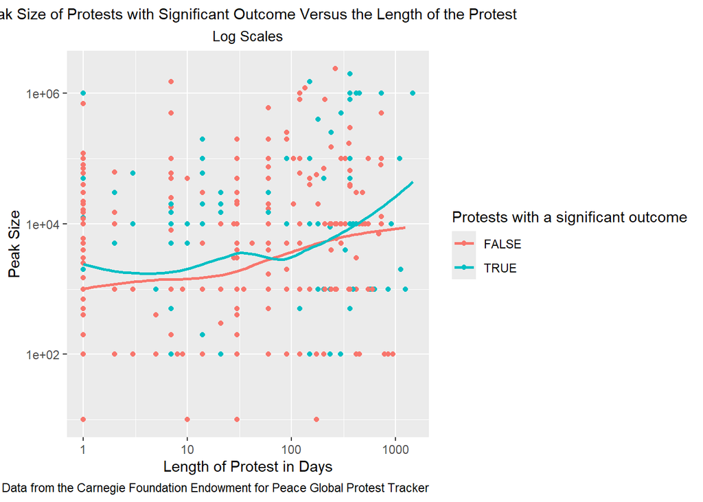

```r
ggplot(gpt_with_pdays_size_fcts, mapping = aes(x = protest_days,
                                               y = peak_size_num,
                                               color = `Protests with a significant outcome`)) +
geom_point() +

scale_x_log10() +
scale_y_log10() +

geom_smooth(se = FALSE, linetype = "solid") +

xlab("Length of Protest in Days") +
ylab("Peak Size") +

ggtitle(label = "Peak Size of Protests with Significant Outcome Versus the Length of the Protest",
        subtitle = "Log Scales") +

labs(caption = "Data from the Carnegie Foundation Endowment for Peace Global Protest Tracker") +
theme(plot.title = element_text(hjust = 0.5, size = 11),
      plot.subtitle = element_text(size = 10, hjust = 0.5)
    )
```

- **Answer:** Yes, the plot shows a positive relationship between peak size of a protest and its duration in days for the presence of the indicator “Protests with a Significant Outcome”.
4. Develop your own question and a plot to answer it. Create the plot and interpret the plot to answer your question. Extra credit for plots with complete labeling.

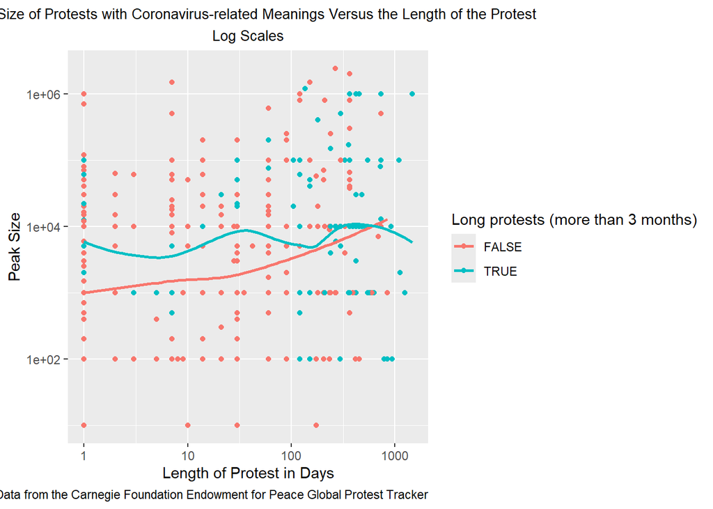

```r
ggplot(gpt_with_pdays_size_fcts, mapping = aes(x = protest_days,
                                               y = peak_size_num,
                                               color = `Long protests (more than 3 months)`)) +
geom_point() +

scale_x_log10() +
scale_y_log10() +

geom_smooth(se = FALSE, linetype = "solid") +

xlab("Length of Protest in Days") +
ylab("Peak Size") +

ggtitle(label = "Peak Size of Protests with Coronavirus-related Meanings Versus the Length of the Protest",
      subtitle = "Log Scales") +

labs(caption = "Data from the Carnegie Foundation Endowment for Peace Global Protest Tracker") +
theme(plot.title = element_text(hjust = 0.5, size = 10),
      plot.subtitle = element_text(size = 10, hjust = 0.5)
    )
```

- **Answer:** For instance, the plot indicates that protests that lasted more than 3 months reached higher pick sizes and duration in days than shorter protests. The relationship between a protest peak size and number of days is somewhat positive.